# Growth Chamber (GC) Soybean Transpiration Analysis

**PI:** Elvis F. Elli · University of Arkansas | **Project:** RIG 2024–2026 | **Report generated:** 2026-05-21

Three growth chamber experiments testing VPD-response in soybean accessions classified by WUE plasticity (Chamarthi et al. 2022). Primary response variable: **transpiration per unit leaf area** (mg m⁻² s⁻¹), measured as pot weight loss over a 40-min treatment window normalised by leaf area. Relative transpiration (0–1) retained for cross-experiment comparison.

## 1. Experiment Overview

| Experiment | Date | Pots | Genotypes | VPD range | Days | Leaf area | Dry matter | Stomatal cond. |
| --- | --- | --- | --- | --- | --- | --- | --- | --- |
| **GC1** | Oct 2024 | 16 (4 geno × 4 rep) | PI471938 (Q1) PI507408 (Q2) PI548431 (Q3) PI603457A (Q4) | 1.0–3.3 kPa (6 levels) | 2 | ✓ | ✓ | ✓ |
| **GC2** | Oct 30–31 2024 | 16 (4 geno × 4 rep) | PI398245 (Q1) PI567488B (Q2) PI377574 (Q3) PI424397 (Q4) | 0.95–3.6 kPa (6 levels) | 2 | ✓ | ✓ | ✗ |
| **GC3** | Nov 2024 | 16 (4 geno × 4 rep) | PI398617 (Q1) PI070229 (Q2) PI423802 (Q3) PI603465C (Q4) | 1.0–3.3 kPa (5 levels) | 2 | ✓ | ✓ | ✗ |

### Genotype classification (Chamarthi et al. 2022)

| Quadrant | WUE class | GC1 | GC2 | GC3 |
| --- | --- | --- | --- | --- |
| Q1 | Plastic, High WUE | PI471938 | PI398245 | PI398617 |
| Q2 | Plastic, Low WUE | PI507408 | PI567488B | PI070229 |
| Q3 | Nonplastic, Low WUE | PI548431 | PI377574 | PI423802 |
| Q4 | Nonplastic, High WUE | PI603457A | PI424397 | PI603465C |

## 2. Methods & QC

### Transpiration measurement

Pots were weighed at the beginning and end of each 40-min VPD treatment window. Weight loss (g ≈ ml) = water transpired. Three weighings were taken per treatment; values are averaged before computing transpiration (as in the processed spreadsheets).

Transpiration per leaf area (mg m⁻² s⁻¹) = Transpiration (ml) × 1000 / leaf area (m²) / 2400 s.

Relative transpiration = Transpiration(T<sub>i</sub>) / max(Transpiration) per pot and day, normalised so the treatment with maximum weight loss = 1.0.

### VPD treatments

- GC1 & GC2: 6 levels, target RH = 80, 68, 56, 44, 32, 20% at 32°C
- GC3: 5 levels, target RH = 80, 68, 56, 44, 32% at 32°C
- Actual VPD measured from chamber probes; values in the cleaned CSV are measured averages per treatment.

### Day effect and primary analysis day

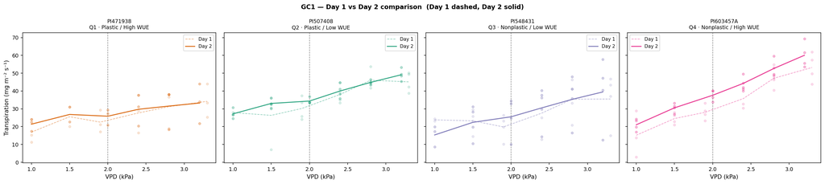

GC1 — Day 1 vs Day 2 comparison. Dashed lines = Day 1 (acclimation); solid = Day 2 (stable).

### Outlier detection

Outliers defined as observations > 2.5 SD from the genotype × treatment group mean (within each experiment, Day 2 only). Flagged values excluded from summary statistics and figures; raw data retained in `GC_combined_clean.csv`.

**Outliers flagged (Day 2, TranspLeafArea): 0**

| Experiment | Genotype | Day 1 mean RT | Day 2 mean RT | Δ (D2−D1) |
| --- | --- | --- | --- | --- |
| GC1 | PI471938 | 0.747 | 0.805 | 0.058 |
| GC1 | PI507408 | 0.720 | 0.776 | 0.056 |
| GC1 | PI548431 | 0.739 | 0.676 | -0.063 |
| GC1 | PI603457A | 0.657 | 0.687 | 0.030 |
| GC2 | PI377574 | 0.789 | 0.792 | 0.003 |
| GC2 | PI398245 | 0.828 | 0.791 | -0.037 |
| GC2 | PI424397 | 0.826 | 0.837 | 0.011 |
| GC2 | PI567488B | 0.797 | 0.802 | 0.005 |
| GC3 | PI070229 | 0.610 | 0.823 | 0.213 |
| GC3 | PI398617 | 0.621 | 0.795 | 0.174 |
| GC3 | PI423802 | 0.600 | 0.841 | 0.241 |
| GC3 | PI603465C | 0.631 | 0.770 | 0.139 |

## 3. GC1 Results

GC1 tested four genotypes (one per WUE quadrant), with 4 replications across 6 VPD levels, measured on 2 consecutive days. Stomatal conductance (LI-600 porometer) was recorded concurrently.

| Genotype | Quadrant | n (Day 2) | TLA mean (mg m⁻² s⁻¹) | TLA SD | Rel.Transp mean | Rel.Transp SD |
| --- | --- | --- | --- | --- | --- | --- |
| PI471938 | Q1 | 17 | 28.18 | 8.04 | 0.79 | 0.16 |
| PI507408 | Q2 | 24 | 38.09 | 7.92 | 0.78 | 0.16 |
| PI548431 | Q3 | 23 | 28.65 | 13.77 | 0.66 | 0.22 |
| PI603457A | Q4 | 24 | 41.03 | 13.93 | 0.69 | 0.23 |

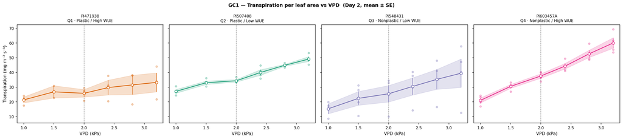

GC1 — Transpiration per leaf area vs VPD (Day 2). Points = individual pots; line = mean ± SE; dashed = Sinclair 2008 VPD threshold (2.0 kPa).

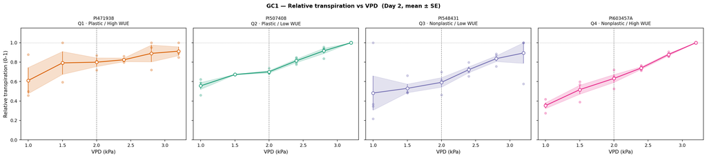

GC1 — Relative transpiration vs VPD (Day 2). Max = 1.0 per pot.

## 4. GC2 Results

GC2 tested a second set of four genotypes (one per quadrant), 4 replications, 6 VPD levels over 2 days (Oct 30–31, 2024). Leaf area, dry matter, and transpiration per leaf area were measured.

**Data note — GC2 anomaly:** Pot 1, Day 1, Treatment 6 (highest VPD) recorded a net weight *gain* (−7.4 ml transpiration), indicating irrigation or measurement error during this window. This value is set to `NA` in `GC2_clean.csv`. All other 191 records are valid.

| Genotype | Quadrant | n (Day 2) | TLA mean (mg m⁻² s⁻¹) | TLA SD | Rel.Transp mean | Rel.Transp SD |
| --- | --- | --- | --- | --- | --- | --- |
| PI377574 | Q3 | 24 | 51.32 | 11.63 | 0.79 | 0.17 |
| PI398245 | Q1 | 24 | 45.59 | 14.01 | 0.79 | 0.21 |
| PI424397 | Q4 | 24 | 47.50 | 8.50 | 0.84 | 0.15 |
| PI567488B | Q2 | 24 | 44.76 | 9.94 | 0.80 | 0.17 |

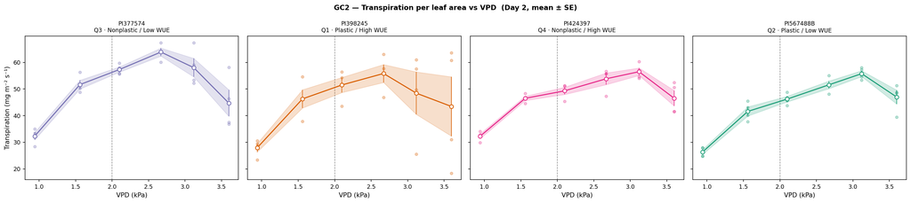

GC2 — Transpiration per leaf area vs VPD (Day 2). Same axes and colour convention as GC1.

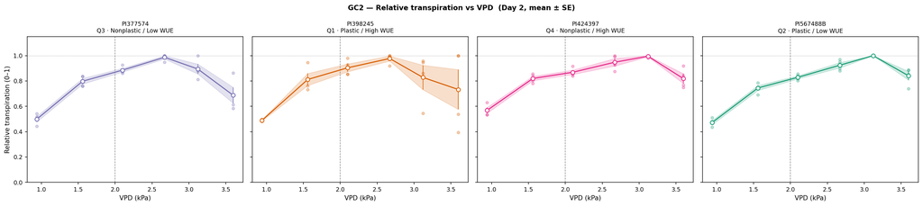

GC2 — Relative transpiration vs VPD (Day 2).

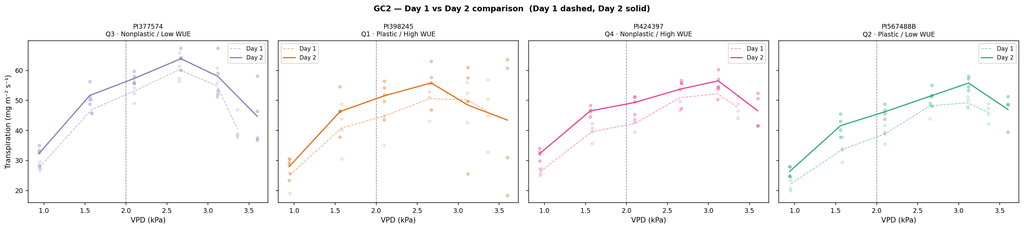

GC2 — Day 1 vs Day 2 comparison. GC2 shows smaller day effect than GC1/GC3.

## 5. GC3 Results

GC3 tested a third set of four genotypes, 4 replications, 5 VPD levels over 2 days (November 2024). No stomatal conductance data.

| Genotype | Quadrant | n (Day 2) | TLA mean (mg m⁻² s⁻¹) | TLA SD | Rel.Transp mean | Rel.Transp SD |
| --- | --- | --- | --- | --- | --- | --- |
| PI070229 | Q2 | 20 | 48.02 | 8.85 | 0.82 | 0.15 |
| PI398617 | Q1 | 20 | 46.89 | 11.07 | 0.79 | 0.18 |
| PI423802 | Q3 | 10 | 53.11 | 8.52 | 0.84 | 0.14 |
| PI603465C | Q4 | 20 | 45.94 | 10.02 | 0.77 | 0.16 |

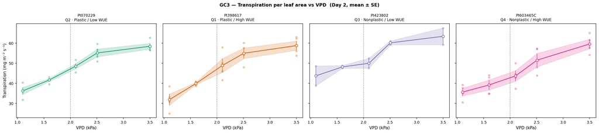

GC3 — Transpiration per leaf area vs VPD (Day 2).

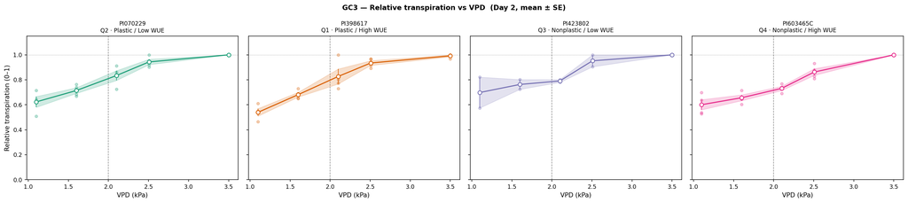

GC3 — Relative transpiration vs VPD (Day 2).

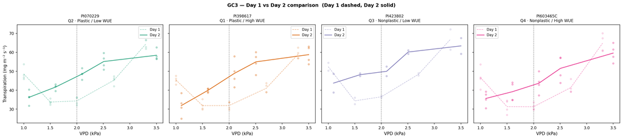

GC3 — Day 1 vs Day 2 comparison. GC3 shows a strong Day 1 deficit (~20–30% lower).

## 6. Overall / Combined Analysis

All three experiments combined: 12 genotypes, 512 observations total (Day 2 n ≈ 256). Quadrant colour coding: Q1 = orange, Q2 = teal, Q3 = purple, Q4 = pink. Experiment line style: GC1 = solid, GC2 = dashed, GC3 = dotted.

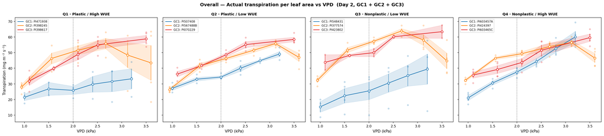

Overall — Actual transpiration per leaf area vs VPD, faceted by WUE quadrant. Each line = one genotype from one experiment.

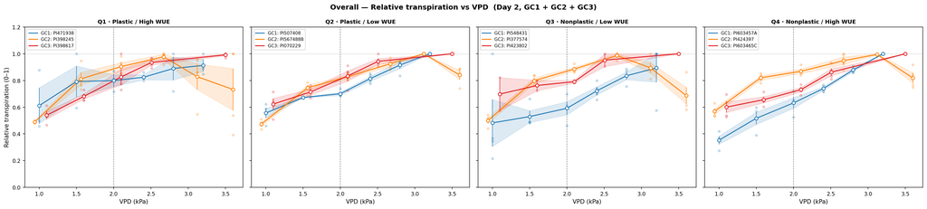

Overall — Relative transpiration vs VPD, faceted by quadrant.

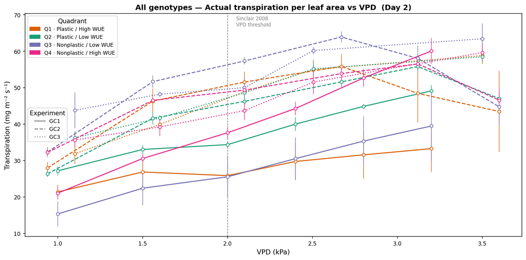

Overall — All genotypes on a single panel. Colour = quadrant, line style = experiment.

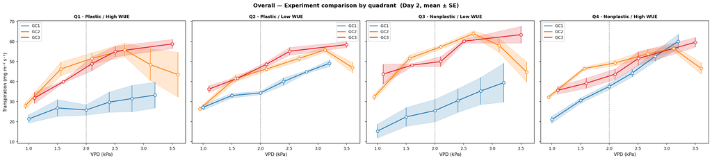

Overall — Experiment-level comparison within each quadrant. Lines represent quadrant-average transpiration per experiment.

## 7. Key Findings

### Descriptive statistics — Day 2, all experiments

| Experiment | Genotype | Quadrant | n | TLA_mean | TLA_sd | RT_mean | RT_sd |
| --- | --- | --- | --- | --- | --- | --- | --- |
| GC1 | PI471938 | Q1 | 17 | 28.18 | 8.04 | 0.79 | 0.16 |
| GC1 | PI507408 | Q2 | 24 | 38.09 | 7.92 | 0.78 | 0.16 |
| GC1 | PI548431 | Q3 | 23 | 28.65 | 13.77 | 0.66 | 0.22 |
| GC1 | PI603457A | Q4 | 24 | 41.03 | 13.93 | 0.69 | 0.23 |
| GC2 | PI377574 | Q3 | 24 | 51.32 | 11.63 | 0.79 | 0.17 |
| GC2 | PI398245 | Q1 | 24 | 45.59 | 14.01 | 0.79 | 0.21 |
| GC2 | PI424397 | Q4 | 24 | 47.50 | 8.50 | 0.84 | 0.15 |
| GC2 | PI567488B | Q2 | 24 | 44.76 | 9.94 | 0.80 | 0.17 |
| GC3 | PI070229 | Q2 | 20 | 48.02 | 8.85 | 0.82 | 0.15 |
| GC3 | PI398617 | Q1 | 20 | 46.89 | 11.07 | 0.79 | 0.18 |
| GC3 | PI423802 | Q3 | 10 | 53.11 | 8.52 | 0.84 | 0.14 |
| GC3 | PI603465C | Q4 | 20 | 45.94 | 10.02 | 0.77 | 0.16 |

## 8. Data Notes

### File structure

| File | Description |
| --- | --- |
| `cleaned_data/GC2_clean.csv` | GC2 primary analysis file extracted from *Data analysis 2.xlsx* Final sheet. 192 rows; one NA (Pot 1, Day 1, T6 weight-gain anomaly). |
| `cleaned_data/GC_combined_clean.csv` | All three experiments combined. 512 rows × 25 columns. Primary analysis file. |
| `raw_data/GC2/GC_experiment_2.xlsx` | Raw weight tracking spreadsheet (Tracking weights sheet). Source for verification. |
| `raw_data/GC2/Data analysis 2.xlsx` | Processed GC2 data (transpiration per pot per treatment, leaf area, dry matter). Source for *GC2_clean.csv*. |

### GC2 data processing

GC2 was processed from the *Final* sheet of `Data analysis 2.xlsx`, which matches the format of GC3's Final sheet. One cell error was detected and corrected: Pot 1, Day 1, Treatment 2 had `Transpiration_ml = 8.553` (incorrect, copy/paste error from Pot 2 T1) — corrected to `13.633` by back-calculation from `TranspLeafArea × LeafArea_squarecm`.

### Scripts

- `scripts/GC2_process_raw.py` — alternative raw-weights extraction (from Tracking weights sheet; superseded by Final sheet extraction)
- `scripts/GC_figures.py` — generates all PNG figures in this report
- `scripts/GC_build_report.py` — generates this HTML report
- `scripts/GC_comprehensive_analysis.R` — R-based analysis (GC1 + GC3; update needed to include GC2)

Generated 2026-05-21 · LT-trait project · Elvis F. Elli, University of Arkansas